# Training the model for the webcam app

We train a neural network **without hidden layers** to predict FairFace’s gender label from a face photo, and save it so the marimo app in this folder can use it.

```r
library(keras3)
set_random_seed(2026)
```

## Data

[FairFace](https://github.com/joojs/fairface): face photos (224 x 224 pixels) labelled with gender (0 = male, 1 = female), balanced across 7 race groups. To keep memory use low we use the first half of the training set (43,372 photos) and the released validation set (10,954 photos). The files are saved in `data/`.

We use these files to create three sets.

| Set | Source | Purpose |
| --- | --- | --- |
| Training | 80% of the training file | Estimate model weights |
| Validation | Remaining 20% of the training file | Compare architectures, hyperparameters and thresholds |
| Held-out evaluation | Released validation file | Report the selected model’s overall and subgroup performance |

Holding out data from model selection reduces the risk of reporting overly optimistic results. The released validation file is a convenient choice for the final evaluation. You can also construct your own training, validation and test splits.

Audit fairness throughout development. Use the training and validation subsets to explore representation and error rates, and examine definitions, privacy and long-term effects from the start. After choosing the model and threshold, use the held-out set for the final performance and fairness estimates. Further changes informed by those results make that set part of model development.

```r
options(timeout = 3600) # ~310 MB in total
url <- "https://huggingface.co/datasets/HuggingFaceM4/FairFace/resolve/main/0.25/"
files <- c(
  train = "train-00000-of-00002-d405faba4f4b9b85.parquet",
  audit = "validation-00000-of-00001-951dbd63c8724ee1.parquet"
)
dir.create("data", showWarnings = FALSE)
for (f in files) {
  if (!file.exists(file.path("data", f))) download.file(paste0(url, f), file.path("data", f), mode = "wb")
}
```

We shrink each photo to 32 x 32 colour pixels by averaging every 7 x 7 block of pixels. Each shrunk photo is stored as a float32 tensor (4 bytes per number instead of R’s 8), so all photos fit in ~0.7 GB and `fit()` can use them without copying.

```r
#' Average each k x k block of an RGB image.
shrink <- function(img, k = 7) {
  n <- nrow(img) / k
  blocks <- aperm(array(img, c(k, n, k, n, 3)), c(1, 3, 2, 4, 5))
  colMeans(blocks, dims = 2)
}

#' Decode a FairFace table into float32 image tensors and gender labels.
read_faces <- function(df) {
  photos <- lapply(df$image$bytes, \(b) op_convert_to_tensor(shrink(jpeg::readJPEG(b)), "float32"))
  list(x = op_stack(photos), y = df$gender)
}

train_data <- arrow::read_parquet(file.path("data", files["train"]))
set.seed(2026)
validation_rows <- sample.int(nrow(train_data), size = floor(0.2 * nrow(train_data)))
train <- read_faces(train_data[-validation_rows, ])
val <- read_faces(train_data[validation_rows, ])
rm(train_data)

c(training = length(train$y), validation = length(val$y))
```

```
  training validation
     34698       8674
```

```r
op_shape(train$x)
```

```
shape(34698, 32, 32, 3)
```

## Model

Input pixels -> output, with no hidden layers (= logistic regression on the pixels). The normalization layer has no weights: it standardizes each photo (mean 0, sd 1), which makes the model less sensitive to lighting.

```r
model <- keras_model_sequential(input_shape = c(32, 32, 3)) |>
  layer_flatten() |>
  layer_layer_normalization(center = FALSE, scale = FALSE) |>
  layer_dense(units = 1, activation = "sigmoid")

model |> compile(
  optimizer = optimizer_adam(learning_rate = 3e-4),
  loss = "binary_crossentropy",
  metrics = "accuracy"
)
model
```

```
Model: "sequential"
┏━━━━━━━━━━━━━━━━━━━━━━━━━━━━━━━━━━━┳━━━━━━━━━━━━━━━━━━━━━━━━━━┳━━━━━━━━━━━━━━━┓
┃ Layer (type)                      ┃ Output Shape             ┃       Param # ┃
┡━━━━━━━━━━━━━━━━━━━━━━━━━━━━━━━━━━━╇━━━━━━━━━━━━━━━━━━━━━━━━━━╇━━━━━━━━━━━━━━━┩
│ flatten (Flatten)                 │ (None, 3072)             │             0 │
├───────────────────────────────────┼──────────────────────────┼───────────────┤
│ layer_normalization               │ (None, 3072)             │             0 │
│ (LayerNormalization)              │                          │               │
├───────────────────────────────────┼──────────────────────────┼───────────────┤
│ dense (Dense)                     │ (None, 1)                │         3,073 │
└───────────────────────────────────┴──────────────────────────┴───────────────┘
 Total params: 3,073 (12.00 KB)
 Trainable params: 3,073 (12.00 KB)
 Non-trainable params: 0 (0.00 B)
```

## Train and inspect validation performance

This baseline uses a fixed learning rate and 30 epochs. Compare training and validation loss to assess overfitting. Use the validation subset when deciding which settings to try or whether to add early stopping.

```r
history <- model |> fit(
  train$x, train$y,
  epochs = 30, batch_size = 256,
  validation_data = list(val$x, val$y),
  verbose = 2
)
```

```
136/136 - 0s - 3ms/step - accuracy: 0.6376 - loss: 0.6460 - val_accuracy: 0.6913 - val_loss: 0.5833
136/136 - 0s - 1ms/step - accuracy: 0.6957 - loss: 0.5825 - val_accuracy: 0.7073 - val_loss: 0.5614
136/136 - 0s - 1ms/step - accuracy: 0.7089 - loss: 0.5654 - val_accuracy: 0.7156 - val_loss: 0.5510
136/136 - 0s - 1ms/step - accuracy: 0.7166 - loss: 0.5552 - val_accuracy: 0.7199 - val_loss: 0.5444
136/136 - 0s - 1ms/step - accuracy: 0.7213 - loss: 0.5481 - val_accuracy: 0.7247 - val_loss: 0.5398
136/136 - 0s - 1ms/step - accuracy: 0.7251 - loss: 0.5428 - val_accuracy: 0.7272 - val_loss: 0.5364
136/136 - 0s - 1ms/step - accuracy: 0.7284 - loss: 0.5386 - val_accuracy: 0.7309 - val_loss: 0.5337
136/136 - 0s - 1ms/step - accuracy: 0.7312 - loss: 0.5352 - val_accuracy: 0.7325 - val_loss: 0.5316
136/136 - 0s - 1ms/step - accuracy: 0.7332 - loss: 0.5323 - val_accuracy: 0.7358 - val_loss: 0.5298
136/136 - 0s - 1ms/step - accuracy: 0.7350 - loss: 0.5299 - val_accuracy: 0.7369 - val_loss: 0.5283
136/136 - 0s - 1ms/step - accuracy: 0.7363 - loss: 0.5278 - val_accuracy: 0.7370 - val_loss: 0.5271
136/136 - 0s - 1ms/step - accuracy: 0.7373 - loss: 0.5259 - val_accuracy: 0.7373 - val_loss: 0.5260
136/136 - 0s - 1ms/step - accuracy: 0.7383 - loss: 0.5243 - val_accuracy: 0.7376 - val_loss: 0.5251
136/136 - 0s - 1ms/step - accuracy: 0.7390 - loss: 0.5228 - val_accuracy: 0.7376 - val_loss: 0.5242
136/136 - 0s - 1ms/step - accuracy: 0.7398 - loss: 0.5215 - val_accuracy: 0.7392 - val_loss: 0.5235
136/136 - 0s - 1ms/step - accuracy: 0.7407 - loss: 0.5203 - val_accuracy: 0.7401 - val_loss: 0.5229
136/136 - 0s - 1ms/step - accuracy: 0.7417 - loss: 0.5191 - val_accuracy: 0.7405 - val_loss: 0.5223
136/136 - 0s - 1ms/step - accuracy: 0.7421 - loss: 0.5181 - val_accuracy: 0.7411 - val_loss: 0.5218
136/136 - 0s - 1ms/step - accuracy: 0.7425 - loss: 0.5172 - val_accuracy: 0.7415 - val_loss: 0.5213
136/136 - 0s - 1ms/step - accuracy: 0.7429 - loss: 0.5163 - val_accuracy: 0.7418 - val_loss: 0.5209
136/136 - 0s - 1ms/step - accuracy: 0.7434 - loss: 0.5155 - val_accuracy: 0.7422 - val_loss: 0.5205
136/136 - 0s - 1ms/step - accuracy: 0.7440 - loss: 0.5147 - val_accuracy: 0.7418 - val_loss: 0.5202
136/136 - 0s - 1ms/step - accuracy: 0.7443 - loss: 0.5140 - val_accuracy: 0.7424 - val_loss: 0.5198
136/136 - 0s - 1ms/step - accuracy: 0.7449 - loss: 0.5134 - val_accuracy: 0.7421 - val_loss: 0.5196
136/136 - 0s - 1ms/step - accuracy: 0.7450 - loss: 0.5127 - val_accuracy: 0.7416 - val_loss: 0.5193
136/136 - 0s - 1ms/step - accuracy: 0.7455 - loss: 0.5121 - val_accuracy: 0.7411 - val_loss: 0.5191
136/136 - 0s - 1ms/step - accuracy: 0.7461 - loss: 0.5116 - val_accuracy: 0.7409 - val_loss: 0.5188
136/136 - 0s - 1ms/step - accuracy: 0.7463 - loss: 0.5110 - val_accuracy: 0.7413 - val_loss: 0.5186
136/136 - 0s - 1ms/step - accuracy: 0.7464 - loss: 0.5105 - val_accuracy: 0.7409 - val_loss: 0.5184
136/136 - 0s - 1ms/step - accuracy: 0.7470 - loss: 0.5100 - val_accuracy: 0.7408 - val_loss: 0.5183
```

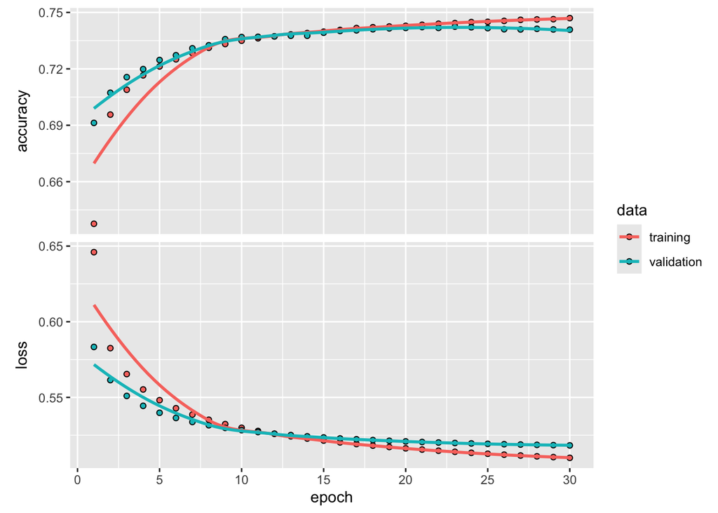

```r
plot(history)
```

**Optional tuning with Optuna**

Optuna is a Python library that tries hyperparameter settings and compares their results. The R package `reticulate` lets you import it and call its functions from R. The code below illustrates the connection and has execution disabled.

Install `optuna` in the Python environment used by `keras3` before trying this extension. `py_config()` shows which environment R uses. If you select an environment with `use_virtualenv()` or `use_python()`, do so before loading Keras.

```r
reticulate::py_config()
optuna <- reticulate::import("optuna")
```

For your MLP, the tuning procedure would be as follows.

1. Write an R function `objective(trial)` that builds a fresh model for each trial. Use methods such as `trial$suggest_int()` for the number of hidden layers or units, and `trial$suggest_float()` for the learning rate.
2. Train each trial on `train` and return a validation metric calculated on `val`. For example, return validation loss and minimise it. Explain why the metric fits your objective.
3. Create a study with `optuna$create_study(direction = "minimize")` and call its `optimize()` method with your objective and a trial budget, such as `n_trials = 20L`. The `L` supplies the integer Python expects.
4. Inspect `study$best_params`, train the selected configuration, and evaluate it on the held-out set after fixing the model and threshold. Keep that set outside the objective function.

This notebook fits the fixed logistic-regression baseline shown above. [Calling Python from R](https://rstudio.github.io/reticulate/articles/calling_python.html) and [Optuna’s introductory tutorial](https://optuna.readthedocs.io/en/stable/tutorial/10_key_features/001_first.html) provide further examples.

## Held-out evaluation

Once the model and decision rule have been chosen, load the released validation file and evaluate the selected model. Keep the `race` and `age` columns in `audit_data` available for the subgroup analysis in the take-home exercise. Its classification errors are measured against FairFace’s labels. Relating these errors to screening eligibility is a question for the audit.

```r
audit_data <- arrow::read_parquet(file.path("data", files["audit"]))
audit <- read_faces(audit_data)
model |> evaluate(audit$x, audit$y, verbose = 0)
```

```
$accuracy
[1] 0.7354391

$loss
[1] 0.5281592
```

## Save

Architecture + weights in one file, which the marimo app loads.

```r
save_model(model, "gender_model.keras", overwrite = TRUE)
```